# Lab 03 - Exploratory Data Analysis

January 22, 2025

# Learning Goals

- Read in and get familiar with the meteorology dataset
- Step through the EDA “checklist” presented in the class slides
- Practice making exploratory graphs

# Lab Description

We will work with the meteorological data presented in lecture. Recall the dataset consists of weather station readings in the contiguous US.

**The objective of the lab is to find the weather station with the highest elevation and look at patterns in the time series of its wind speed and temperature.**

# Steps

### 1. Read in the data

First download and then read in with `data.table` function `fread()`

```r
# ***Uploaded manually to resolve issue
# download.file(
 # "https://raw.githubusercontent.com/JSC370/JSC370-2025/main/data/met/met_all.gz",
  # destfile = "met_all.gz",
  # method   = "curl",
  # timeout  = 60
  # )
```

```r
met <- data.table::fread("met_all.gz")
```

### 2. Check the dimensions, headers, footers. How many columns, rows are there?

- Note you may use R or Python

```r
# <place your code here>
print(dim(met))
```

```
## [1] 2377343      30
```

```r
print(head(met))
```

```
##    USAFID  WBAN  year month   day  hour   min   lat      lon  elev wind.dir
##     <int> <int> <int> <int> <int> <int> <int> <num>    <num> <int>    <int>
## 1: 690150 93121  2019     8     1     0    56  34.3 -116.166   696      220
## 2: 690150 93121  2019     8     1     1    56  34.3 -116.166   696      230
## 3: 690150 93121  2019     8     1     2    56  34.3 -116.166   696      230
## 4: 690150 93121  2019     8     1     3    56  34.3 -116.166   696      210
## 5: 690150 93121  2019     8     1     4    56  34.3 -116.166   696      120
## 6: 690150 93121  2019     8     1     5    56  34.3 -116.166   696       NA
##    wind.dir.qc wind.type.code wind.sp wind.sp.qc ceiling.ht ceiling.ht.qc
##         <char>         <char>   <num>     <char>      <int>         <int>
## 1:           5              N     5.7          5      22000             5
## 2:           5              N     8.2          5      22000             5
## 3:           5              N     6.7          5      22000             5
## 4:           5              N     5.1          5      22000             5
## 5:           5              N     2.1          5      22000             5
```

[output cut: 17 more lines]

```r
print(tail(met))
```

```
##    USAFID  WBAN  year month   day  hour   min    lat      lon  elev wind.dir
##     <int> <int> <int> <int> <int> <int> <int>  <num>    <num> <int>    <int>
## 1: 726813 94195  2019     8    31    18    56 43.650 -116.633   741       NA
## 2: 726813 94195  2019     8    31    19    56 43.650 -116.633   741       70
## 3: 726813 94195  2019     8    31    20    56 43.650 -116.633   741       NA
## 4: 726813 94195  2019     8    31    21    56 43.650 -116.633   741       10
## 5: 726813 94195  2019     8    31    22    56 43.642 -116.636   741       10
## 6: 726813 94195  2019     8    31    23    56 43.642 -116.636   741       40
##    wind.dir.qc wind.type.code wind.sp wind.sp.qc ceiling.ht ceiling.ht.qc
##         <char>         <char>   <num>     <char>      <int>         <int>
## 1:           9              C     0.0          5      22000             5
## 2:           5              N     2.1          5      22000             5
## 3:           9              C     0.0          5      22000             5
## 4:           5              N     2.6          5      22000             5
## 5:           1              N     2.1          1      22000             1
```

[output cut: 17 more lines]

- *There are 2,377,343 rows or observations, and 30 columns or variables.*

### 3. Take a look at the variables in the dataset. What kind of variables are there?

```r
# <place your code here>
str(met)
```

```
## Classes 'data.table' and 'data.frame':   2377343 obs. of  30 variables:
##  $ USAFID           : int  690150 690150 690150 690150 690150 690150 690150 690150 690150 690150 ...
##  $ WBAN             : int  93121 93121 93121 93121 93121 93121 93121 93121 93121 93121 ...
##  $ year             : int  2019 2019 2019 2019 2019 2019 2019 2019 2019 2019 ...
##  $ month            : int  8 8 8 8 8 8 8 8 8 8 ...
##  $ day              : int  1 1 1 1 1 1 1 1 1 1 ...
##  $ hour             : int  0 1 2 3 4 5 6 7 8 9 ...
##  $ min              : int  56 56 56 56 56 56 56 56 56 56 ...
##  $ lat              : num  34.3 34.3 34.3 34.3 34.3 34.3 34.3 34.3 34.3 34.3 ...
##  $ lon              : num  -116 -116 -116 -116 -116 ...
##  $ elev             : int  696 696 696 696 696 696 696 696 696 696 ...
##  $ wind.dir         : int  220 230 230 210 120 NA 320 10 320 350 ...
##  $ wind.dir.qc      : chr  "5" "5" "5" "5" ...
##  $ wind.type.code   : chr  "N" "N" "N" "N" ...
##  $ wind.sp          : num  5.7 8.2 6.7 5.1 2.1 0 1.5 2.1 2.6 1.5 ...
```

[output cut: 17 more lines]

- *There are integer variables like the station number (USAFID), datetime information (year, month, day, hour, min); and numerical variables about the location (lat, lon), temperature, etc; as well as character variables for information like sky condition.*

### 4. Take a closer look at the key variables.

- Are there missing data? If so, make sure they are coded correctly.
- Are there any unusual values that look suspicious? Recall the temperature values in the lecture.

```r
# <place your code here>

# Check All Variables
# print(summary(met))

# Check Key Variables
print(summary(met$elev))
```

```
##    Min. 1st Qu.  Median    Mean 3rd Qu.    Max.
##   -13.0   101.0   252.0   415.8   400.0  9999.0
```

```r
print(summary(met$wind.sp))
```

```
##    Min. 1st Qu.  Median    Mean 3rd Qu.    Max.    NA's
##    0.00    0.00    2.10    2.46    3.60   36.00   79693
```

```r
print(summary(met$temp))
```

```
##    Min. 1st Qu.  Median    Mean 3rd Qu.    Max.    NA's
##  -40.00   19.60   23.50   23.59   27.80   56.00   60089
```

```r
# Check Location
print(summary(met$lat))
```

```
##    Min. 1st Qu.  Median    Mean 3rd Qu.    Max.
##   24.55   33.97   38.35   37.94   41.94   48.94
```

```r
print(summary(met$lon))
```

```
##    Min. 1st Qu.  Median    Mean 3rd Qu.    Max.
## -124.29  -98.02  -91.71  -92.15  -82.99  -68.31
```

```r
# Change Encoding
met$elev[met$elev == 9999] <- NaN
print(summary(met$elev))
```

```
##    Min. 1st Qu.  Median    Mean 3rd Qu.    Max.    NA's
##     -13     101     252     413     400    4113     710
```

### 5. Check the data against an external data source and make adjustments.

- Check that the range of elevations make sense.
- Google or ChatGPT is your friend here.
- Fix any problems that arise in your checks.

```r
# <place your code here>

# Remove Data with Error
met_ss <- met[temp == -40.00, .(hour, lat, lon, elev, wind.sp)]
print(dim(met_ss))
```

```
## [1] 36  5
```

```r
print(summary(met_ss))
```

```
##       hour            lat             lon              elev       wind.sp
##  Min.   : 0.00   Min.   :29.12   Min.   :-89.55   Min.   :36   Min.   : NA
##  1st Qu.: 2.75   1st Qu.:29.12   1st Qu.:-89.55   1st Qu.:36   1st Qu.: NA
##  Median : 5.50   Median :29.12   Median :-89.55   Median :36   Median : NA
##  Mean   : 5.50   Mean   :29.12   Mean   :-89.55   Mean   :36   Mean   :NaN
##  3rd Qu.: 8.25   3rd Qu.:29.12   3rd Qu.:-89.55   3rd Qu.:36   3rd Qu.: NA
##  Max.   :11.00   Max.   :29.12   Max.   :-89.55   Max.   :36   Max.   : NA
##                                                                NA's   :36
```

```r
met <- met[temp > -40]

# Remove Missing Values
mean(is.na(met))
```

```
## [1] 0.03582776
```

```r
met_clean <- met[!is.nan(met$wind.sp) & !is.nan(met$temp) & !is.nan(met$elev), ]
```

### 6. Calculate summary statistics

Remember to keep the initial question in mind. We want to pick out the weather station with maximum elevation and examine its wind speed and temperature.

Some ideas: 1. select the weather station with maximum elevation; 2. look at the correlation between temperature and wind speed; and 3. look at the correlation between temperature and wind speed with hour and day of the month.

```r
# <place your code here>

# Find the Station with Maximum Elevation
setorder(met_clean, -elev)
max_elev <- met_clean[1]$elev
highest <- met_clean[elev == max_elev, .(USAFID, hour, day, elev, wind.sp, temp)]
print(summary(highest))
```

```
##      USAFID            hour            day            elev
##  Min.   :720385   Min.   : 0.00   Min.   : 1.0   Min.   :4113
##  1st Qu.:720385   1st Qu.: 6.00   1st Qu.: 8.0   1st Qu.:4113
##  Median :720385   Median :12.00   Median :16.0   Median :4113
##  Mean   :720385   Mean   :11.66   Mean   :16.1   Mean   :4113
##  3rd Qu.:720385   3rd Qu.:18.00   3rd Qu.:24.0   3rd Qu.:4113
##  Max.   :720385   Max.   :23.00   Max.   :31.0   Max.   :4113
##
##     wind.sp            temp
##  Min.   : 0.000   Min.   : 1.00
##  1st Qu.: 4.100   1st Qu.: 6.00
##  Median : 6.700   Median : 8.00
##  Mean   : 7.245   Mean   : 8.13
##  3rd Qu.: 9.800   3rd Qu.:10.00
##  Max.   :21.100   Max.   :15.00
##  NA's   :168
```

```r
# Compute Correlation
cor_temp_wind <- cor(highest$temp, highest$wind.sp, use = "complete")
print(cor_temp_wind)
```

```
## [1] -0.09373843
```

```r
# Consider Time Series Data
cor_temp_hour <- cor(highest$temp, highest$hour, use = "complete")
cor_temp_day <- cor(highest$temp, highest$day, use = "complete")
cor_wind_hour <- cor(highest$wind.sp, highest$hour, use = "complete")
cor_wind_day <- cor(highest$wind.sp, highest$day, use = "complete")
print(c(cor_temp_day, cor_temp_hour, cor_wind_day, cor_wind_hour))
```

```
## [1] -0.003857766  0.439726080  0.364307915  0.088073152
```

### 7. At what elevation is the highest weather station?

```r
# <place your code here>
print(max_elev)
```

```
## [1] 4113
```

- *The weather station 720385 has the highest elevation at 4113m. The temperature and hour has a stronger correlation than with day, and the wind speed and day has a stronger correlation than with hour.*

### 8. Exploratory graphs: Distributions

We should look at the distributions of all of the key variables (elevation, temp, wind speed) to make sure there are no remaining issues with the data.

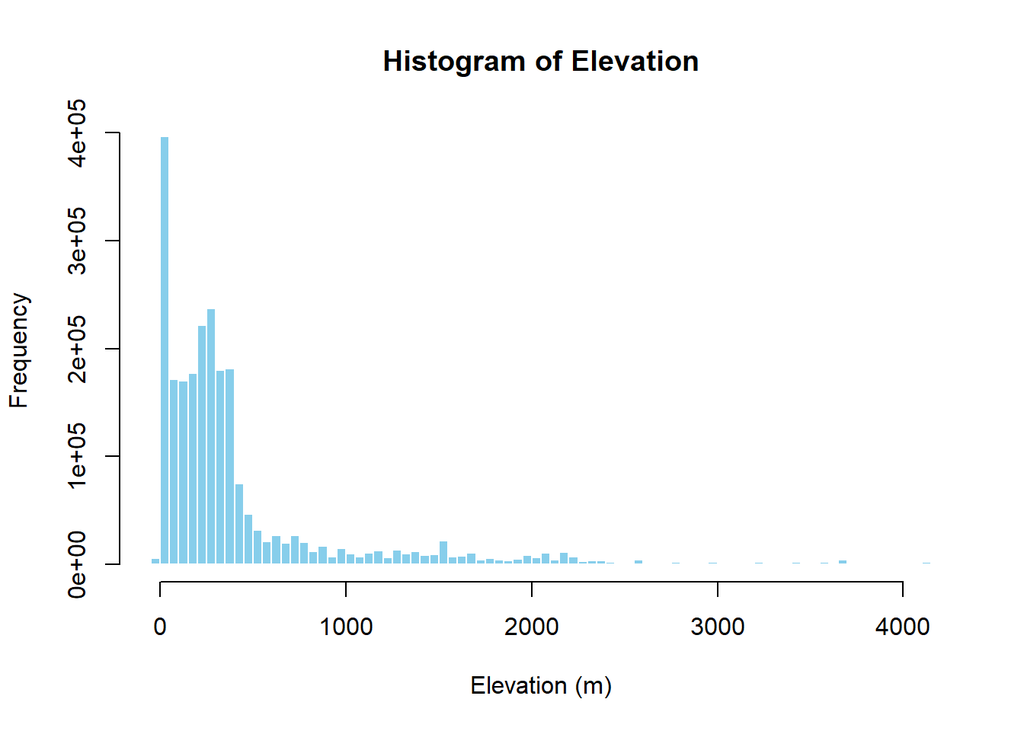

```r
# <place your code here>

# par(mfrow = c(1, 3))

# Elevation
# met_clean$log_elev <- log(met_clean$elev + 1)
hist(met_clean$elev,
     main = "Histogram of Elevation",
     xlab = "Elevation (m)",
     col = "skyblue",
     border = "white",
     breaks = 80)
```

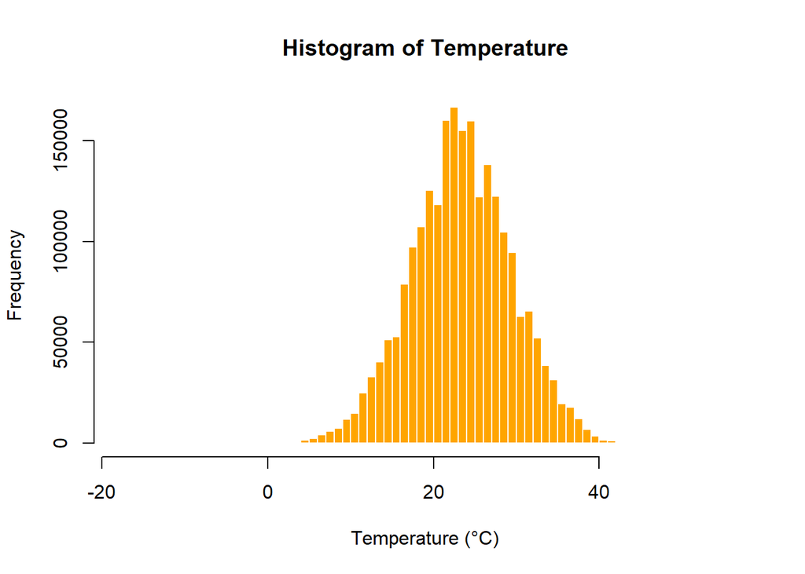

```r
# Temperature
hist(met_clean$temp,
     main = "Histogram of Temperature",
     xlab = "Temperature (°C)",
     col = "orange",
     border = "white",
     breaks = 80)
```

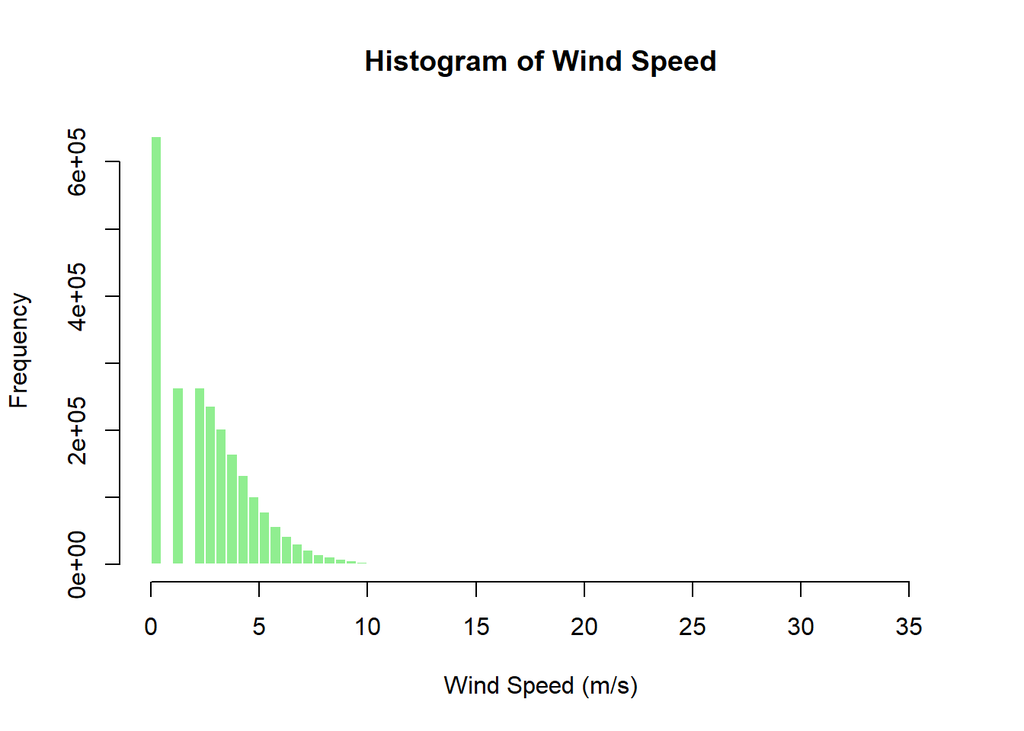

```r
# Wind Speed
# met_clean$log_windsp <- log(met_clean$wind.sp + 1)
hist(met_clean$wind.sp,
     main = "Histogram of Wind Speed",
     xlab = "Wind Speed (m/s)",
     col = "lightgreen",
     border = "white",
     breaks = 80)
```

One thing we should consider for later analyses is to log transform wind speed and elevation as the are very skewed.

- *Both elevation and wind speed have skewed distribution, while temperature shows a almost perfect normal distribution. The graphs are reasonable, and there are no obvious remaining issues in the data.*

### 9. Exploratory graphs: Time Series

Look at the time series of temperature and wind speed at this location. For this we will need to create a date-time variable for the x-axis.

```r
# <place your code here>
met_clean$date <- with(met_clean, ymd_hm(paste(year, month, day, hour, min, spe='')))
summary(met_clean$date)
```

```
##                       Min.                    1st Qu.
## "2019-08-01 00:00:00.0000" "2019-08-08 18:15:00.0000"
##                     Median                       Mean
## "2019-08-16 12:53:00.0000" "2019-08-16 12:12:57.4698"
##                    3rd Qu.                       Max.
## "2019-08-24 05:53:00.0000" "2019-08-31 23:59:00.0000"
```

With the date-time variable we can plot the time series of temperature and wind speed. Summarize any trends that you see in these time series plots.

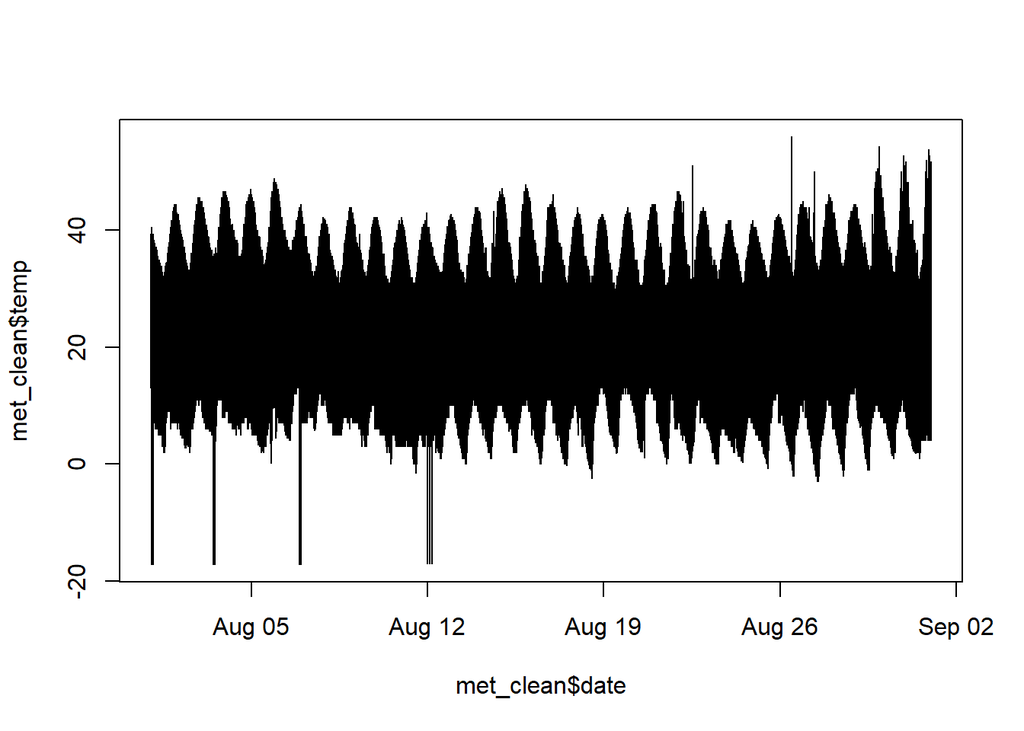

```r
# <place your code here>
met_clean <- met_clean[order(date)]
plot(met_clean$date, met_clean$temp, type = "l")
```

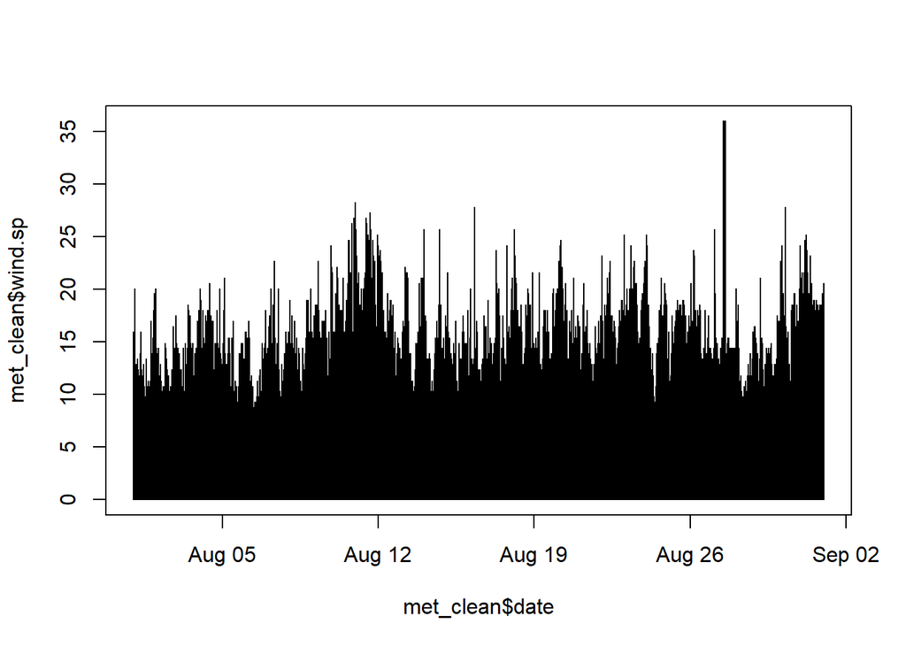

```r
plot(met_clean$date, met_clean$wind.sp, type = "l")
```

- *The temperatures are mostly distributed between 0 and 40 degrees with some outliers. The temp plot also corresponds to the correlation computation, we can see the hourly trends are much more obvious than the change throughout the month. On the other hand, there is one outlier sticking out in the wind speed time series plot that might be worth investigating.*

### 10. Exploratory graphs: Map

Where is the weather station with highest elevation located? (i.e. make a map!)

```r
# <place your code here>
# hint: make use of leaflet

# Identify Station
setorder(met_clean, -elev)
highest_elev_station <- met_clean[1]
lat <- highest_elev_station$lat
lon <- highest_elev_station$lon
elev <- highest_elev_station$elev
station_name <- highest_elev_station$USAFID

# Create a leaflet map
leaflet() %>%
  addTiles() %>%
  addMarkers(
    lng = lon, lat = lat,
    popup = paste(
      "<b>Station Name:</b>", station_name, "<br>",
      "<b>Elevation:</b>", elev, "m"
    ),
    label = paste("Highest Elevation: ", elev, "m")
  ) %>%
  setView(lng = lon, lat = lat, zoom = 10)
```

[interactive chart not shown]